# RNA-seq and ChIP-seq data analysis

Pascal

17 octobre 2018

This work is licensed under a [Creative Commons Attribution 4.0 International License](http://creativecommons.org/licenses/by/4.0/).

## Data and session setup

*In this document, the commands corresponding to module loading are intended to be run on the genologin cluster (see [bioinformatic platform](http://bioinfo.genotoul.fr/))*  
*Alternatively, install individual tools on your system (links provided in this document) or use [bioconda](https://bioconda.github.io/)*

### Data presentation

The data analyzed here come from GSE70408 (Chen et al., 2015).

Transcription by **RNA polymerase II** (RNAPII) involves several steps:

- Promoter opening under the effect of **transcription factors** (TFs) and their **cofactors** (chromatin modifiers and remodelers, mediator)
- Assembly of the **preinitiation complex** (PIC)
- Promoter **escape**
- For a large fraction of metazoan genes: **Promoter-proximal pausing** of RNAPII
- Productive **elongation**
- Transcription **termination**
- At least in certain cases RNAPII **recycling**

The article describes the role of the **transcription elongation factor PAF1** on RNAPII promoter-proximal pausing. The authors use different genome-wide approaches in Human and Drosophila cells to study the location of PAF1 and the effect of its knock-down on RNAPII distribution and RNA expression.

Here, we focus on the RNA-seq data and some of the ChIP-seq data produced in the article. In order to keep computations at an acceptable level, we will only keep chromosomes 19 and 20 which cover ~120Mb (comparable to the size of Drosophila melanogaster or Arabidopsis thaliana whole genome).

### Session setup

Prepare the folders in which the analysis will be performed:

```bash
basedir="/work/pmartin/PROJECTS/RNAseqChIPseq"
# replace pmartin by your username if you work on GenoToul cluster

mkdir -p ${basedir}/RNAseq/Aligned
mkdir -p ${basedir}/ChIPseq/Aligned
mkdir -p ${basedir}/data
mkdir -p ${basedir}/bank
mkdir -p ${basedir}/log
mkdir -p ${basedir}/tmp

selectedChromosomes="chr19 chr20"
```

### Sequences, annotations and indexes

The genome sequences and annotations are downloaded from [Gencode](https://www.gencodegenes.org/).

#### Genome sequence (fasta)

Download the whole genome sequence:

```bash
cd ${basedir}/bank
wget ftp://ftp.ebi.ac.uk/pub/databases/gencode/Gencode_human/release_28/GRCh38.primary_assembly.genome.fa.gz
gunzip GRCh38.primary_assembly.genome.fa.gz
```

Then:

- index the fasta file with [samtools](http://www.htslib.org/)
- extract the sequences of chr19 and chr20 an index
- delete the large fasta file containing the whole genome sequence

```bash
cd ${basedir}/bank
module load bioinfo/samtools-1.8 #on genologin cluster

samtools index GRCh38.primary_assembly.genome.fa

samtools faidx \
    GRCh38.primary_assembly.genome.fa \
    ${selectedChromosomes} \
    > \
    GRCh38.primary_assembly.chr1920.fa

samtools index GRCh38.primary_assembly.chr1920.fa

rm GRCh38.primary_assembly.genome.fa
```

#### Annotations (GTF file):

We download the annotations:

```bash
cd ${basedir}/bank
wget ftp://ftp.ebi.ac.uk/pub/databases/gencode/Gencode_human/release_28/gencode.v28.annotation.gtf.gz
gunzip gencode.v28.annotation.gtf.gz
```

And select the annotations from chr19 and chr20 only:

```bash
awk '$1 ~ /^##.+/ || $1=="chr19"|| $1=="chr20"' \
    gencode.v28.annotation.gtf \
    > \
    gencode.v28.annotation_chr1920.gtf

#Cleanup
rm gencode.v28.annotation.gtf
```

#### STAR index:

STAR is a powerful short read aligner dedicated to RNA-seq (Dobin et al., 2013). While a very fast aligner, it requires relatively large amounts of RAM.  
[HiSat2](https://ccb.jhu.edu/software/hisat2/index.shtml) is a popular alternative (Kim et al., 2015; Pertea et al., 2016)

Before running alignments with STAR, we need to generate genome indexes:

```bash
mkdir -p ${basedir}/bank/star_index
module load bioinfo/STAR-2.6.0c #on genologin cluster

STAR \
    --runThreadN 4 \
    --runMode genomeGenerate \
    --genomeDir ${basedir}/bank/star_index \
    --genomeFastaFiles ${basedir}/bank/GRCh38.primary_assembly.chr1920.fa \
    --sjdbGTFfile ${basedir}/bank/gencode.v28.annotation_chr1920.gtf \
```

#### Bowtie2 index:

Popular short read aligners include [Bowtie2](http://bowtie-bio.sourceforge.net/bowtie2) (Langmead and Salzberg, 2012) and [bwa](http://bio-bwa.sourceforge.net/) (Li and Durbin, 2009, 2010).

We use bowtie2 here and build the genome index using:

```bash
mkdir -p ${basedir}/bank/bowtie2_index
module load bioinfo/bowtie2-2.3.4.1 #on genologin cluster

bowtie2-build \
    --threads 4 \
    --seed 123 \
    ${basedir}/bank/GRCh38.primary_assembly.chr1920.fa \
    ${basedir}/bank/bowtie2_index/GRCh38.primary_assembly.chr1920 \
```

#### Transcripts sequences:

Some recent so-called “alignment-free” methods such as [kallisto](https://pachterlab.github.io/kallisto/) (Bray et al., 2016) and [Salmon](https://combine-lab.github.io/salmon/) (Patro et al., 2017) do not perform a classical alignment of reads on the genome prior to assigning reads to genomic features (genes/transcripts). Rather, they rely on matching catalogs of k-mers obtained from the transcriptome on one hand and the reads on the other hands.

For these methods, we need the sequences of all transcripts:

```bash
cd ${basedir}/bank
wget ftp://ftp.ebi.ac.uk/pub/databases/gencode/Gencode_human/release_28/gencode.v28.transcripts.fa.gz
```

### Raw data (reads)

The [EBI European Nucleotide Archive](https://www.ebi.ac.uk/ena) is a convenient way to access NGS data. In particular, it includes a copy of the [NCBI Short Read archive](https://www.ncbi.nlm.nih.gov/sra).

Individual fastq files can be downloaded, such as:

```bash
wget ftp://ftp.sra.ebi.ac.uk/vol1/fastq/SRR208/008/SRR2084598/SRR2084598.fastq.gz
wget ftp://ftp.sra.ebi.ac.uk/vol1/fastq/SRR208/009/SRR2084599/SRR2084599.fastq.gz
```

We can also download the SRA file (lighter) and then extract the fastq file using the [SRA toolkit](https://www.ncbi.nlm.nih.gov/books/NBK158900/) but this is rather slow too:

```bash
wget ftp://ftp.sra.ebi.ac.uk/vol1/srr/SRR208/008/SRR2084598
fastq-dump SRR2084598
```

**Faster download with aspera client:** A very nice tutorial on how to download such large files faster is available [here](https://www.biostars.org/p/325010/).

First install the [Aspera client](http://www.asperasoft.com/en/downloads/2).

Then go to the [EBI ENA](https://www.ebi.ac.uk/ena) and search for `GSE70408`  
In the experiment page, select columns: *Study accession*, *Library Layout*, *FASTQ files (FTP)* and *Experiment title* and export the table as text.

Now we use [R](https://www.r-project.org/) to extract the files we want and prepare the links for fast download:

```r
basedir="/work/pmartin/PROJECTS/RNAseqChIPseq"

#All the files:
gse70408 <- read.table(file.path(basedir, "tmp", "PRJNA288695.txt"),
                       sep="\t", header=T)

#Selected files:
selgse70408 <- gse70408[c(
                    grep("total.RNA", gse70408[,2]),
                    grep("PAF1_WT", gse70408[,2])),]

#Format the links for aspera client:
selgse70408$fasp_link <- gsub("ftp.sra.ebi.ac.uk",
                              "era-fasp@fasp.sra.ebi.ac.uk:",
                              selgse70408$fastq_ftp)

#save the links
write.table(selgse70408$fasp_link,
            file.path(basedir, "tmp", "downloadSelectedGSE70408.txt"),
            row.names = FALSE, col.names = FALSE, quote = FALSE)
```

Then download all the selected files using:

```bash
cat $basedir/tmp/downloadSelectedGSE70408.txt | while read LIST
  do
  $HOME/.aspera/connect/bin/ascp \
    -QT \
    -l 300m \
    -P33001 \
    -i $HOME/.aspera/connect/etc/asperaweb_id_dsa.openssh \
    $LIST \
    .
  done
```

I have then filtered these fastq files to keep only reads mapping to chromosomes 19 and 20 (plus a few % of unmapped reads to make it more realistic 😉). The filtered reads are in the `data` folder.

## RNA-seq

### Raw reads - QC - Trimming

#### QC

Quality controls on raw reads can be done with [fastqc](https://www.bioinformatics.babraham.ac.uk/projects/fastqc/).  
More advanced QC can also be performed using e.g. [RSeQC](http://rseqc.sourceforge.net/).  
Note that in RNA-seq (and other applications as well) it is often desirable to compare the QC obtained from different samples. [MultiQC](https://multiqc.info/) is an excellent tool to facilite this task.

```bash
mkdir -p ${basedir}/RNAseq/rawQC
module load bioinfo/FastQC_v0.11.7 #on genologin cluster

for fn in SRR20845{96..99}
  do
  fastqc \
    -o ${basedir}/RNAseq/rawQC \
    ${basedir}/data/${fn}_chr1920.fq.gz
  done
```

#### Trimming

In many cases RNA-seq reads do not require trimming. If you notice a lot of adapter contamination, you can use [cutadapt](https://cutadapt.readthedocs.io/en/stable/guide.html) or [Trimmomatic](http://www.usadellab.org/cms/?page=trimmomatic) for example.

Note that fastp, a recently developed tool integrates automatic trimming (and adapter detection) with pre- and post-filtering QC (Chen et al., 2018).

### Alignment

Align the reads to the “genome” (here only chr19 and chr20) using STAR:

```bash
module load bioinfo/STAR-2.6.0c #on genologin cluster

for fn in SRR208459{6..9}
do

    STAR \
        --runMode alignReads \
        --runThreadN 4 \
        --genomeDir ${basedir}/bank/star_index \
        --readFilesIn ${basedir}/data/${fn}_chr1920.fq.gz\
        --readFilesCommand zcat \
        --outFileNamePrefix ${basedir}/RNAseq/Aligned/${fn}_chr1920_ \
        --outSAMtype BAM SortedByCoordinate \
        --quantMode TranscriptomeSAM GeneCounts \
        --outWigType bedGraph

done
```

The option `--quantmode TranscriptomeSAM` produces the alignments in the coordinates of the transcriptome.  
The option `--quantmode GeneCounts` produces a table with counts of reads per gene.  
The option `--outWigType bedGraph` produces bedgraph files that can be used to vizualize the data in a genome browser.

### Counting and differential expression analysis

In addition to STAR (see above), there are several other options to count reads (including splice reads) on genomic features such as genes. An early and still popular solution with python is [HTseq](https://github.com/simon-anders/htseq). Another efficient tool is [featureCounts](http://subread.sourceforge.net/) that is also accessible in R via the [Rsubread](http://bioconductor.org/packages/release/bioc/html/Rsubread.html) package.

Here we illustrate the use of the `summarizeOverlaps` function of the [GenomicAlignments](http://bioconductor.org/packages/release/bioc/html/GenomicAlignments.html) package from Bioconductor.

First we need the annotations (here the exons of each gene). We could use the annotations provided by Bioconductor:

```r
#Prepare the annotations:
library(TxDb.Hsapiens.UCSC.hg38.knownGene)
txdb <- GenomeInfoDb::keepSeqlevels(TxDb.Hsapiens.UCSC.hg38.knownGene,
                                    c("chr19", "chr20"),
                                    pruning.mode = "coarse")
exBygn_hg38 <- exonsBy(txdb, by="gene")
```

But to remain consistent (e.g. with STAR GeneCounts) we will make our own TxDb object from the [Gencode](https://www.gencodegenes.org/) GTF file using the [GenomicFeatures](http://bioconductor.org/packages/release/bioc/html/GenomicFeatures.html) package:

```r
library(GenomicFeatures)
txdb <- makeTxDbFromGFF(file.path(basedir,
                                  "bank",
                                  "gencode.v28.annotation_chr1920.gtf"))
exBygn_gc <- exonsBy(txdb, by="gene")
```

```r
#module load system/R-3.4.3 #on genologin cluster
library(GenomicAlignments)

# Bam files:
bampath <- "/work/pmartin/PROJECTS/RNAseqChIPseq/RNAseq/Aligned"
bamfn <- BamFileList(dir(bampath, pattern="*.sortedByCoord.out.bam$", full=TRUE))

ct <- summarizeOverlaps(exBygn_gc,
                        bamfn,
                        mode = "Union",
                        singleEnd=TRUE,
                        ignore.strand = TRUE)
colnames(ct) <- paste0("SRR208459",6:9)
```

The counts are obtained using:

```r
head(assays(ct)$counts)
```

|  | SRR2084596 | SRR2084597 | SRR2084598 | SRR2084599 |
| --- | --- | --- | --- | --- |
| ENSG00000000419.12 | 1127 | 1767 | 1104 | 1618 |
| ENSG00000004776.12 | 6 | 8 | 4 | 0 |
| ENSG00000004777.18 | 31 | 55 | 48 | 42 |
| ENSG00000005007.12 | 2675 | 3560 | 2343 | 2940 |
| ENSG00000005206.16 | 260 | 309 | 430 | 387 |
| ENSG00000006015.17 | 224 | 314 | 300 | 360 |

The other slots in ct:

```r
slotNames(ct)
#[1] "rowRanges"       "colData"         "assays"          "NAMES"
#[5] "elementMetadata" "metadata"
```

The percentage of reads from the BAM files that were assigned to a gene model can be obtained with:

```r
100 * colSums(assays(ct)$counts) / countBam(bamfn)$records
# ~78-83%
```

Using these counts, we can perform a differential expression analysis using e.g. [DESeq2](http://bioconductor.org/packages/release/bioc/html/DESeq2.html).  
For this, we first prepare the data:

```r
library(DESeq2)
colData <- DataFrame(SampleName = colnames(ct),
                     condition = factor(rep(c("shPAF1","Ctrol"), each=2)),
                     row.names = colnames(ct))

dds <- DESeqDataSetFromMatrix(countData = assays(ct)$counts,
                              colData = colData,
                              design = ~ condition)
```

Then, we remove the genes that have 0 counts for all samples. We can add other filters here, such as keeping only protein-coding genes or removing genes overlapping with a *blacklist*.

```r
dds <- dds[rowSums(assay(dds))!=0,]
```

And we perform the analysis:

```r
dds <- DESeq(dds)
```

We get the number of DE genes (at FDR=5%) using:

```r
sum(results(dds)$padj<0.05, na.rm = TRUE)
```

```
## [1] 198
```

The most significant genes can be vizualized using:

```r
head(results(dds)[order(results(dds)$pvalue),])
```

| GeneID | baseMean | log2FoldChange | lfcSE | stat | pvalue | padj |
| --- | --- | --- | --- | --- | --- | --- |
| ENSG00000006712.14 | 729.6 | -3.4 | 0.23 | -15.0 | 9e-51 | 1e-47 |
| ENSG00000101255.10 | 2023.3 | -1.7 | 0.20 | -8.3 | 9e-17 | 6e-14 |
| ENSG00000125826.20 | 726.8 | -2.1 | 0.25 | -8.3 | 1e-16 | 6e-14 |
| ENSG00000105289.14 | 286.6 | -2.2 | 0.28 | -7.6 | 2e-14 | 8e-12 |
| ENSG00000179262.9 | 790.0 | -1.6 | 0.22 | -7.4 | 1e-13 | 4e-11 |
| ENSG00000187994.13 | 310.0 | -2.1 | 0.29 | -7.4 | 1e-13 | 4e-11 |

The DE genes can now be further studied (e.g. enrichment of GO annotations or specific pathways?) and integrated with other measurements (e.g. ChIP-seq)

### Estimates of expression levels

While **counts** are the preferred measure to perform differential expression analysis, they depend on both sequencing depth and transcript size. Thus, they are not adapted to estimate the “absolute” expression of a gene and compare it to th eexpression of other genes. Count data must thus be corrected for:

- **Sequencing depth**: A sample sequenced more deeply will have more reads mapping to all genes
- **Gene (or transcript) length**: Longer genes will have more reads mapping to them than shorter genes

**Sequencing Depth:**  
Methods to analyze differential gene expression (e.g. [DESeq2](http://bioconductor.org/packages/release/bioc/html/DESeq2.html), [edgeR](http://bioconductor.org/packages/release/bioc/html/edgeR.html) or [limma](http://bioconductor.org/packages/release/bioc/html/limma.html) with appropriate normalization for count-based data) all take into account sequencing depth, also refered to as *“library size”*. While `colSums` on the count matrix is an intuitive solution, more elaborate methods such as TMM (Trimmed mean of M-values, (Robinson and Oshlack, 2010)) should be considered, especially in te presence of heterogeneity between samples.

**Gene/Transcript(s) length:**  
The necessity to scale the data by gene/transcript size raises questions such as:

- If a gene produces different transcripts that share exons, and the counts are at the gene level, which size should we use?
- If a gene produces different transcripts in different samples (because e.g. splicing or initiation/termination of transcription have been affected by an experimental condition), should we scale by different gene sizes between samples?

Because of such issues (and because of the stochasticity in the data), the actual gene expression levels can only be estimated from the count data. We can’t reliably tell if 2 genes with very close expression measures are actually expressed at different levels, but we can form groups of genes that faithfully represent e.g. low, moderate or high expression levels.

Here, we use a rather simple way to estimate gene size. We take the median length of all annotated transcripts for each gene:

```r
# Get exons by trancripts:
exBytx <- exonsBy(txdb, by="tx")
# Get size of each transcript:
txSize <- sum(width(exBytx))
# Get transcripts per gene and unlist
txsByGene <- unlist(transcriptsBy(txdb, "gene"))
# Split transcripts sizes by gene name
SizetxBygn <- split(txSize[as.character(txsByGene$tx_id)],
                    names(txsByGene))
#Get median transcript length by gene
GeneLength <- sapply(SizetxBygn, median)
GeneLengthInKb <- GeneLength / 1e3
```

We can calculate RPKM using:

```r
#geneLengths is in Kb
rpkm_fun <- function(countMatrix, geneLengths) {
#sanity check:
    if (!identical(rownames(countMatrix),
                   names(geneLengths))) {
        stop("names of countMatrix and geneLengths don't match")
    }
#calculate rpkm:
    x <- t( t(countMatrix) * 1e6 / colSums(countMatrix) ) # get RPM
    rpkm.mat <- x / geneLengths # scale for gene length
    return(rpkm.mat)
}

RPKM <- rpkm_fun(assays(ct)$counts,
                 GeneLengthInKb[rownames(ct)])
```

We can obtain the same results using [edgeR](http://bioconductor.org/packages/release/bioc/html/edgeR.html) functions:

```r
library(edgeR)
edg <- DGEList(assays(ct)$counts,
               group = factor(rep(c("shPAF1","Ctrol"), each=2)))
edg <- edgeR::calcNormFactors(edg)

edgRPKM <- rpkm(edg,
                gene.length = GeneLength[rownames(ct)],
                normalized.lib.sizes = FALSE,
                log = FALSE,
                prior.count = 0)

identical(round(RPKM,9), round(edgRPKM, 9)) #TRUE
```

But the arguments of the `rpkm` function allow further control, such as using **TMM** normalization (use `normalized.lib.sizes = TRUE` because TMM is the default for `calcNormFactors`) and getting log(RPKM) (by adding a small count to zero values). Note that edgeR also has a `rpkmByGroup` function.

One issue with RPKM values is that the sum of RPKMs differs between samples. This led to the introduction of the **TPM** (Transcript per million, see this [video](https://youtu.be/TTUrtCY2k-w) for a very clear explanation on the difference between RPKM/FPKM and TPM).  
The rationale behind the normalization (scaling for both gene length and sequencing depth) is exactly the same but the order in which the scalings are performed differs: in TPM, we first scale the data by gene length and then scale for sequencing depth (i.e. sample sums of RPK or reads per kilobase).  
Using the rough estimates that we have of gene lengths, we can calculate TPM from the count matrix using this [code by Michael Love](https://support.bioconductor.org/p/91218/):

```r
#geneLengths is in Kb
tpm_fun <- function(countMatrix, geneLengths) {
    x <- countMatrix / geneLengths #get RPK
    tpm.mat <- t( t(x) * 1e6 / colSums(x) ) #Scale for sequencing depth
    return(tpm.mat)
}

TPM <- tpm_fun(assays(ct)$counts,
               GeneLengthInKb[rownames(ct)])
```

TPM values can also be obtained using RSEM, a software that also provides credibility intervals for these values as well as estimates for isoforms abundances (Li and Dewey, 2011).

More recently, it was realized that classical spliced-read alignment on the genome was not indispensable to evaluate where the reads come from and thus quantify gene/transcript expression. Based on this idea, [Kallisto](https://pachterlab.github.io/kallisto/) (Bray et al., 2016) and then [Salmon](https://combine-lab.github.io/salmon/) (Patro et al., 2017) were developed. They use the concept of pseudoalignment which relies on the use of kmers and graphs to evaluate from which gene/transcript the read originated, the only essential information necessary for quantification. These two softwares appear to give highly similar results in published benchmarks. The package [tximport](http://bioconductor.org/packages/release/bioc/html/tximport.html) can be used to inmport the results of RSEM, Salmon or Kallisto in R (Soneson et al., 2015).

### Signal files for genome browser

*“Signal files”* contain some kind of counting (possibly normalized by library size) of the number of reads that are aligned at each position of the genome. They are generally in [wig](https://genome.ucsc.edu/goldenpath/help/wiggle.html) / [bigwig](https://genome.ucsc.edu/goldenpath/help/bigWig.html) format or in [bedgraph](https://genome.ucsc.edu/goldenpath/help/bedgraph.html) format.  
We have already obtained these files above via the STAR command (see Alignment). We can also obtain such files using the `coverage` function in R:

```r
mybam <- readGAlignments(file.path(bampath,
                                   "SRR2084596_chr1920_Aligned.sortedByCoord.out.bam"))
# !! for RNA-seq do not convert the reads to granges because spliced reads would results in coverage on the introns
covbam <- coverage(grglist(mybam))
```

At this step it is generally necessary to normalize the coverage vector (e.g. by library size). We can also combine different profiles (e.g. calculate group averages, differences or ratios of profiles, etc.).

The [rtracklayer](http://bioconductor.org/packages/release/bioc/html/rtracklayer.html) package is extremely useful to import/export genomic data in R. We use it to export the profile in bigwig format:

```r
rtracklayer::export(covbam, "myProfile.bigwig")
```

The signal files can then be vizualized on a genome browser such as [IGV](http://software.broadinstitute.org/software/igv/), [jbrowse](https://jbrowse.org/) or [gbrowse](https://www.gbrowse.org/).

## ChIP-seq

Useful resources to start with ChIP-seq include the guidelines published by the [ENCODE](https://www.encodeproject.org/) and [modENCODE](http://www.modencode.org/) consortia (Landt et al., 2012), reviews on ChIP-seq data analysis (e.g. Bailey et al., 2013) and online courses (e.g. [using Bioconductor](https://www.bioconductor.org/help/course-materials/2016/CSAMA/lab-5-chipseq/Epigenetics.html)).

### Raw reads - QC - Trimming

PAF1 ChIP-seq sample has been sequenced over 3 runs (single-end). The raw sequences were merged:

```bash
zcat ${basedir}/data/SRR208453{7..9}.fastq.gz > ${basedir}/data/PAF1_ChIPseq.fastq
```

Again, to limit computation times, all reads were aligned to the genome (with [Bowtie2](http://bowtie-bio.sourceforge.net/bowtie2/index.shtml)) and the reads mapping to chromosomes 19 and 20 (+ some unmapped reads) were kept and converted back to fastq.  
The corresponding file is: `${basedir}/data/PAF1_ChIPseq_chr1920.fq.gz`

Analysis of the reads with [fastqc](https://www.bioinformatics.babraham.ac.uk/projects/fastqc/) shows a high quality of the sequences and a very low adapter contamination.

```bash
mkdir -p ${basedir}/ChIPseq/rawQC
module load bioinfo/FastQC_v0.11.7 #on genologin cluster

  fastqc \
    -o ${basedir}/ChIPseq/rawQC \
    ${basedir}/data/PAF1_ChIPseq_chr1920.fq.gz
```

Based on this, we decide to not trim the reads and proceed with alignment.

### Alignment

We use [Bowtie2](http://bowtie-bio.sourceforge.net/bowtie2) to align the reads on chr19 and chr20:

```bash
module load bioinfo/bowtie2-2.3.3.1 #on genologin cluster

#decompress fastq file:
gunzip -c \
  ${basedir}/data/PAF1_ChIPseq_chr1920.fq.gz \
  > \
  ${basedir}/data/PAF1_ChIPseq_chr1920.fq

#variable
fastqfile="${basedir}/data/PAF1_ChIPseq_chr1920.fq"
outfile="${basedir}/ChIPseq/Aligned/PAF1_ChIPseq_chr1920.sam"
bowtie2Index="${basedir}/bank/bowtie2_index/GRCh38.primary_assembly.chr1920"

#run bowtie2
bowtie2 \
  --very-sensitive \
  -p 4 \
  -x "${bowtie2Index}" \
  -U "${fastqfile}" \
  -S "${outfile}"
```

Then we convert the SAM file to BAM using [samtools](http://www.htslib.org/):

```r
module load bioinfo/samtools-1.4 #on genologin
samtools view -b ${outfile} \
    | \
    samtools sort \
        --threads 4 \
        -o ${outfile%%.sam}.bam -
```

We can then mark the duplicate reads using e.g. [Picard tools](https://broadinstitute.github.io/picard/):

```bash
module load bioinfo/picard-2.14.1 #sets the ${PICARD} variable on genologin

java -Xmx8g -jar $PICARD MarkDuplicates \
  INPUT=${outfile%%.sam}.bam \
  OUTPUT=${outfile%%.sam}_MarkedDup.bam \
  METRICS_FILE=${outfile%%.sam}_MarkedDupMetrics.log \
  ASSUME_SORT_ORDER=coordinate

#Cleanup (we keep only the file with read duplicates marked)
rm ${outfile}
rm ${outfile%%.sam}.bam
```

Duplicates could be directly removed with the option `REMOVE_DUPLICATES` of Picard or using samtools. Here there are relatively few duplicate reads (~2-3%). The benefits of removing duplicate reads is not always obvious (Chen et al., 2012) so we choose to keep them here.

Index the BAM file:

```r
AlignedReads="${outfile%%.sam}_MarkedDup.bam"
samtools index ${AlignedReads}
```

After indexing, we can use samtools to get various statistics on the aligned reads:

```r
#aligned reads by chromosome using idxstats
samtools idxstats ${AlignedReads} > ${AlignedReads%%.bam}.idxstats

#QC passed/failed reads using flagstat
samtools flagstat ${AlignedReads} > ${AlignedReads%%.bam}.flagstat

#More statistics (here removing duplicates for illustrating purposes)
samtools stats \
  --remove-dups \
${AlignedReads} > \
${AlignedReads%%.bam}.bamstats

#Plots  from these statistics can be generated using the plot-bamstats function present in the misc subfolder of samtools
```

### Signal files

Signal files for downstream analysis and visualization in a genome browser can be obtained using different tools such as: [bedtools coverage/coverageBed](https://bedtools.readthedocs.io/en/latest/content/tools/coverage.html) or [deeptools bamCoverage](https://deeptools.readthedocs.io/en/develop/content/tools/bamCoverage.html).  
As illustrated below, they can also be obtained with the peak caller [MACS2](https://github.com/taoliu/MACS).

In single-end sequencing, the 5’-> 3’ orientation of sequencing and the short read length creates a bias in read distribution between the +/- strands (Wilbanks and Facciotti, 2010):

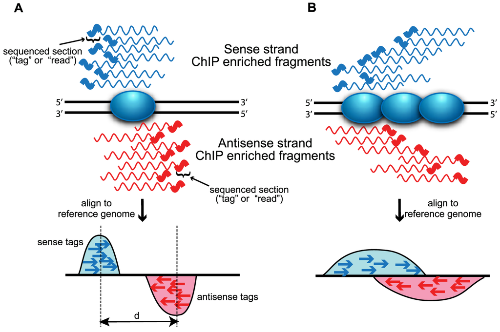

A. Punctuate mark (e.g. TF)  
B. Broad mark (e.g. RNAPII)

Because we want the signal file to represent the location of the protein that was IPed, we need to either extend the reads to the fragment size d, or to shift them by d/2.  
There are different methods to estimate the fragment size from a single-end ChIP-seq library (e.g. [SPP](http://compbio.med.harvard.edu/Supplements/ChIP-seq/) peak caller widely used by ENCODE).

In R, we can use:

```r
# cd ${basedir}/ChIPseq/Aligned
# module load system/R-3.4.3 #on genologin cluster (choose the right version for you)
library(chipseq)
library(GenomicAlignments)

#import BAM
paf1bam <- readGAlignments("PAF1_ChIPseq_chr1920_MarkedDup.bam")
#estimate fragment length
fraglen <- chipseq::estimate.mean.fraglen(granges(paf1bam)) #method="correlation" for SPP-like
#get coverage on extended reads (~200bp)
paf1cov <- coverage(resize(granges(paf1bam), 200))
```

If necessary, this coverage vector can be normalized (e.g. by library size) or combined with other data (e.g. input DNA, other ChIP-seq profiles). It can then be exported using:

```r
library(rtracklayer)
rtracklayer::export(paf1cov, "PAF1_coverage.bigwig")
```

```r
saveRDS(paf1cov, "../RData/paf1cov.rds")
```

**About fragment length:**  
Here, we have single-end reads but when paired-end reads are available, it is a good idea to look at the distribution of fragment lengths. In ChIP-seq and depending on the fragmentation and library preparation steps, fragment sizes carries biologically meaningfull information. For example, highly accessible regions such as enhancers or active promoters are more likely to yield small ChIP-seq fragments. Nucleosomes-derived fragments are typically in the ~150bp range. Longer fragments may be enriched for compact heterochromatin.

### Peak calling

There are several tools to perform peak calling.  
[MACS2](https://github.com/taoliu/MACS) and [SPP](https://www.encodeproject.org/software/spp/) are heavily used by the [ENCODE](https://www.encodeproject.org/) project.  
We can also mention [SICER](https://home.gwu.edu/~wpeng/Software.htm) for braod regions or [GEM/GPS](http://groups.csail.mit.edu/cgs/gem/) for punctuate regions.

Here we illustrate the use of MACS2:

```bash
module load system/Python-2.7.2 #on genologin cluster

macs2 callpeak \
    -t ${AlignedReads} \
    -n macs2_PAF1 \
    -g dm \
    --nomodel \
    --extsize 200 \
    -p 0.01 \
    -B \
&> ${basedir}/log/macs2_PAF1.log
```

- We use the `-g dm` argument here because chr19+chr20 are ~ the size of the Drosophila genome
  - We use the options: `--nomodel --extsize 200` because we have already estimated fragment length (and MACS2 model has too few peaks here to reliably estimate the fragment size)
  - With the `-B` argument, MACS2 also produces bedgraph files for fragments pileup, -log10(pvalue) and -log10(qalue).
  - The `-p 0.01` argument relaxes a bit the default threshold of MACS2 (q-value<0.05) in order to detect more peaks

**IDR pipeline:**  
The [ENCODE](https://www.encodeproject.org/) consortium has developed a pipeline to call peaks that are reproducible between replicates and pseudo-replicates (obtained by random sampling) called the [IDR pipeline](https://www.encodeproject.org/software/idr/).

### Peak annotation

Annotating peaks means evaluating where these peaks are located relative to genomic features (e.g. promoters, gene body, exon/intron, etc.). Here we use Bioconductor tools to do it:

First we import the peaks obtained with MACS2 using the package [genomation](http://bioconductor.org/packages/release/bioc/html/genomation.html):

```r
# cd ${basedir}/ChIPseq/Aligned
# module load system/R-3.4.3 #on genologin cluster (choose the right version for you)
paf1Peaks <- genomation::readNarrowPeak("macs2_PAF1_peaks.narrowPeak")
```

We use the annotations obtained previously from the GTF file with the `makeTxDbFromGFF` from [GenomicFeatures](http://bioconductor.org/packages/release/bioc/html/GenomicFeatures.html).

The [ChIPseeker](http://bioconductor.org/packages/release/bioc/html/ChIPseeker.html) package is used to annotate the peaks. The [ChIPpeakAnno](http://bioconductor.org/packages/release/bioc/html/ChIPpeakAnno.html) is also interesting for this task.

```r
paf1peakanno <- ChIPseeker::annotatePeak(paf1Peaks,
                                         tssRegion=c(-1000, 1000),
                                         TxDb=txdb)
```

Note that there is a default priority in genomic annotations (i.e., by default, a peak annotated as *“Promoter”* will not be annotated in another genomic category). This can be modified with the `genomicAnnotationPriority` argument.

The results of the enrichment can be visualized using a barplot:

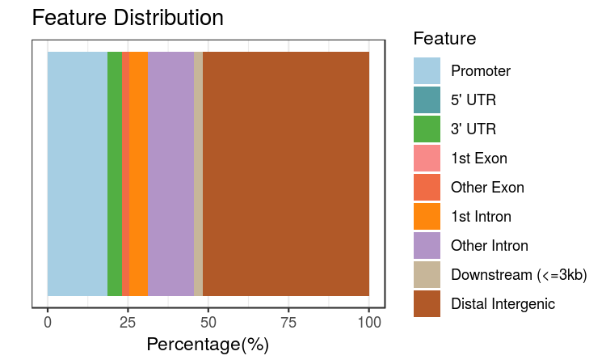

```r
#png("course/figs/plotAnnoBar_paf1peakanno.png", width=750, height=450, res=150)
ChIPseeker::plotAnnoBar(paf1peakanno)
#dev.off()
```

But the overlaps in peak annotations are best illustrated with an [Upset plot](https://github.com/hms-dbmi/UpSetR) (Conway et al., 2017; Lex et al., 2014):

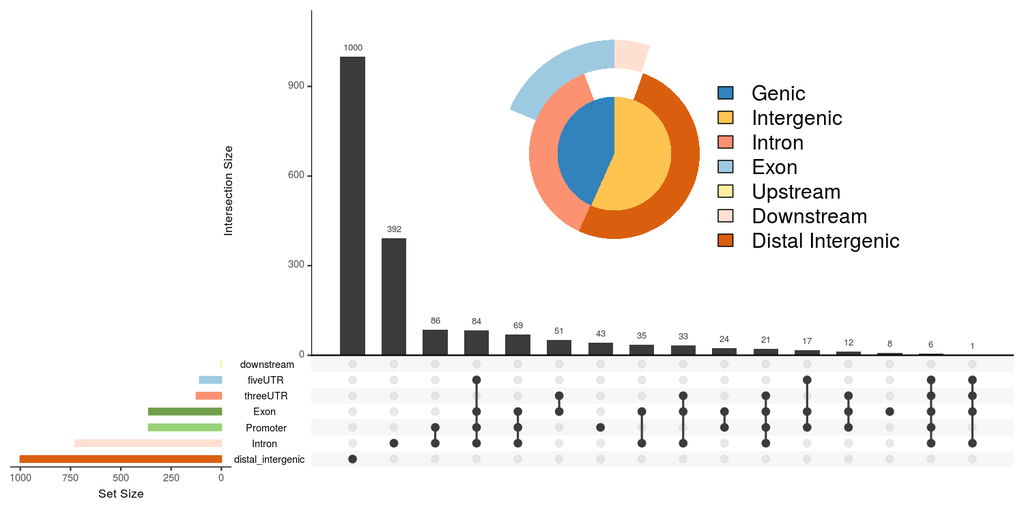

```r
#png("course/figs/upset_paf1peakanno.png", width=1500, height=750, res=150)
ChIPseeker::upsetplot(paf1peakanno, vennpie=TRUE)
#dev.off()
```

### Heatmaps and average profiles

Another way to look at the data is to extract profiles around specific genomic features and to represent them as heatmaps an average profiles. The [genomation](http://bioconductor.org/packages/release/bioc/html/genomation.html) and [EnrichedHeatmap](https://bioconductor.org/packages/release/bioc/html/EnrichedHeatmap.html) packages provides interesting functions for this task. For illustrative purpose we do it more “manually” here:

We use the `paf1cov` object created earlier.

And obtain the location of the TSS from the `txdb` object:

```r
txBygn <- GenomicFeatures::transcriptsBy(txdb, "gene")
tss <- unique(unlist(promoters(txBygn, upstream=0, downstream=1)))
```

We can now extract the profiles of PAF1 in a region of TSS+/-1Kb using:

```r
paf1prof <- paf1cov[tss + 1000]
names(paf1prof) <- tss$tx_id
paf1prof[strand(tss)=="-"] <- lapply(paf1prof[strand(tss)=="-"], rev)
```

We convert this `RleList` as a `matrix`:

```r
paf1profmat <- matrix(as.numeric(unlist(paf1prof, use.names=FALSE)),
                                 nrow = length(paf1prof),
                                 byrow = TRUE,
                                 dimnames = list(names(paf1prof), NULL))
```

We can plot this matrix as a heatmap using e.g. the [EnrichedHeatmap](https://bioconductor.org/packages/release/bioc/html/EnrichedHeatmap.html) package. By simplicity we only plot the top 500 genes in terms of PAF1 signal in the region between the TSS and the TSS+500bp.  
We first select the genes

```r
avgpaf1 <- apply(paf1profmat[,1001:1501], 1, mean)
paf1profmat_sel <- paf1profmat[order(avgpaf1, decreasing = TRUE),][1:500,]
```

Then we average the signal in bins of 10bp:

```r
paf1profmat_sel <- t(apply(paf1profmat_sel, 1, tapply,
                         c(rep(1:100, each = 10),
                           101,
                           rep(102:201, each = 10)),
                         mean))
```

And convert the matrix so that it is recognized by the `EnrichedHeatmap` function:

```r
paf1TSSmat <- paf1profmat_sel[,-101]
attr(paf1TSSmat, "upstream_index") <- 1:100
attr(paf1TSSmat, "target_index") <- numeric(0)
attr(paf1TSSmat, "downstream_index") <- 101:200
attr(paf1TSSmat, "extend") <- c(1000,1000)
attr(paf1TSSmat, "signal_name") <- "PAF1"
attr(paf1TSSmat, "target_name") <- "TSS"
attr(paf1TSSmat, "target_is_single_point") <- TRUE
class(paf1TSSmat) = c("normalizedMatrix", "matrix")
```

Then we plot them:

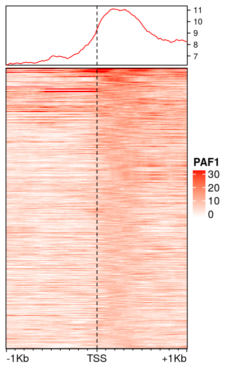

```r
library(EnrichedHeatmap)
col_fun = circlize::colorRamp2(c(0, 30), c("white", "red"))
#png("course/figs/hmap_paf1TSSmat.png", width=450, height=750, res=150)
    EnrichedHeatmap(paf1TSSmat,
                row_order=1:nrow(paf1TSSmat),
                col=col_fun,
                name="PAF1",
                axis_name=c('-1Kb','TSS','+1Kb'))
#dev.off()
```

The `EnrichedHeatmap` already provides an average profile over the region. But we can easily obtain it as follow:

We calculate the average signal at each position:

```r
avgprof <- apply(paf1profmat, 2, mean)
```

And plot the average profile:

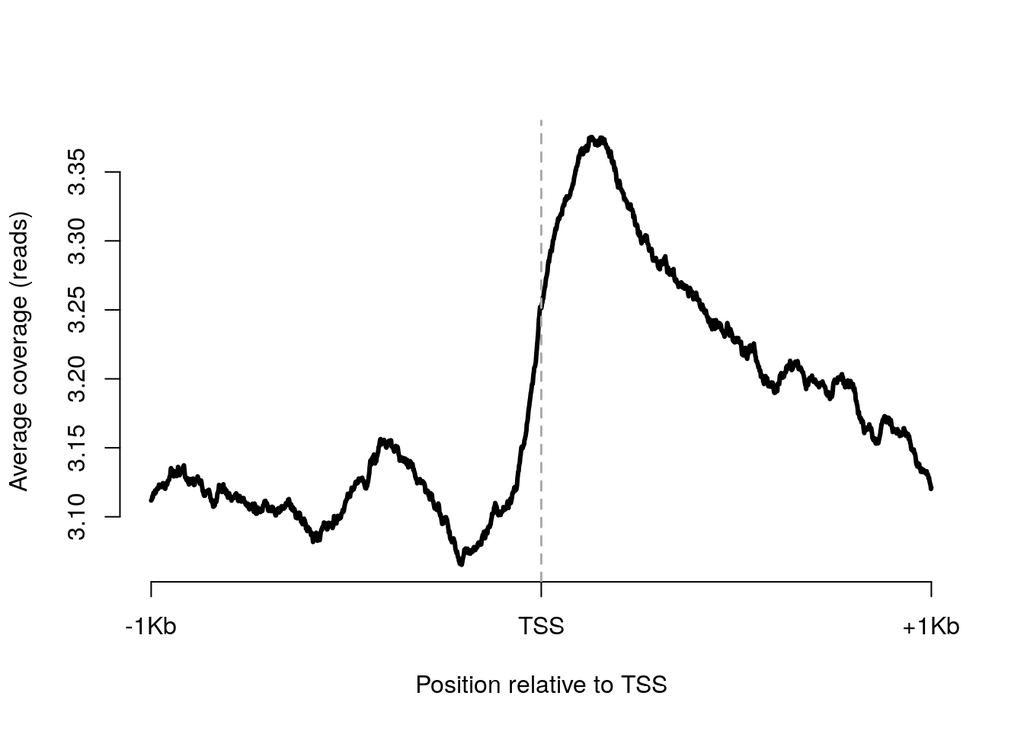

```r
plot(-1000:1000,
     avgprof,
     type="l",
     lwd=3,
     axes=FALSE,
     xlab="Position relative to TSS",
     ylab="Average coverage (reads)")
axis(side=1,
     at=c(-1000, 0, 1000),
     labels = c("-1Kb", "TSS", "+1Kb"))
axis(side = 2)
abline(v=0, lty=2, lwd=1.5, col="darkgrey")
```

### Sequences for motif search

Using the Biostrings package, we can easily extract sequences to be analyzed for motif enrichment.  
Here we extract the core promoter sequences (TSS-500bp to TSS) of genes with a PAF1 peak at less than 1Kb from their TSS:

Select the TSS with a PAF1 peak at less than 1Kb:

```r
tssWithPAF1 <- tss[overlapsAny(tss+1000, paf1Peaks)]
```

Load the genome sequence

```r
library(BSgenome.Hsapiens.UCSC.hg38)
```

Extract the core promoters of these TSS:

```r
selseq <- BSgenome::getSeq(Hsapiens,
                           promoters(tssWithPAF1,
                                     upstream=500,
                                     downstream=1))
```

And export the sequences as a fasta file:

```r
writeXStringSet(selSeq, "../data/Prom_tssWithPAF1.fa")
```

These sequences can then be used to search for motifs using e.g. [RSAT](http://pedagogix-tagc.univ-mrs.fr/rsat/RSAT_portal.html) or [MEME](http://meme-suite.org/)

## References

Bailey, T., Krajewski, P., Ladunga, I., Lefebvre, C., Li, Q., Liu, T., Madrigal, P., Taslim, C., and Zhang, J. (2013). Practical guidelines for the comprehensive analysis of ChIP-seq data. PLoS Comput. Biol. *9*, e1003326.

Bray, N.L., Pimentel, H., Melsted, P., and Pachter, L. (2016). Near-optimal probabilistic RNA-seq quantification. Nat. Biotechnol. *34*, 525–527.

Chen, F.X., Woodfin, A.R., Gardini, A., Rickels, R.A., Marshall, S.A., Smith, E.R., Shiekhattar, R., and Shilatifard, A. (2015). PAF1, a Molecular Regulator of Promoter-Proximal Pausing by RNA Polymerase II. Cell *162*, 1003–1015.

Chen, S., Zhou, Y., Chen, Y., and Gu, J. (2018). Fastp: An ultra-fast all-in-one fastq preprocessor. Bioinformatics *34*, i884–i890.

Chen, Y., Negre, N., Li, Q., Mieczkowska, J.O., Slattery, M., Liu, T., Zhang, Y., Kim, T.K., He, H.H., Zieba, J., et al. (2012). Systematic evaluation of factors influencing ChIP-seq fidelity. Nat. Methods *9*, 609–614.

Conway, J.R., Lex, A., and Gehlenborg, N. (2017). UpSetR: an R package for the visualization of intersecting sets and their properties. Bioinformatics *33*, 2938–2940.

Dobin, A., Davis, C.A., Schlesinger, F., Drenkow, J., Zaleski, C., Jha, S., Batut, P., Chaisson, M., and Gingeras, T.R. (2013). STAR: ultrafast universal RNA-seq aligner. Bioinformatics *29*, 15–21.

Kim, D., Langmead, B., and Salzberg, S.L. (2015). HISAT: a fast spliced aligner with low memory requirements. Nat. Methods *12*, 357–360.

Landt, S.G., Marinov, G.K., Kundaje, A., Kheradpour, P., Pauli, F., Batzoglou, S., Bernstein, B.E., Bickel, P., Brown, J.B., Cayting, P., et al. (2012). ChIP-seq guidelines and practices of the ENCODE and modENCODE consortia. Genome Res. *22*, 1813–1831.

Langmead, B., and Salzberg, S.L. (2012). Fast gapped-read alignment with Bowtie 2. Nat. Methods *9*, 357–359.

Lex, A., Gehlenborg, N., Strobelt, H., Vuillemot, R., and Pfister, H. (2014). UpSet: Visualization of Intersecting Sets. IEEE Trans Vis Comput Graph *20*, 1983–1992.

Li, B., and Dewey, C.N. (2011). RSEM: accurate transcript quantification from RNA-Seq data with or without a reference genome. BMC Bioinformatics *12*, 323.

Li, H., and Durbin, R. (2009). Fast and accurate short read alignment with Burrows-Wheeler transform. Bioinformatics *25*, 1754–1760.

Li, H., and Durbin, R. (2010). Fast and accurate long-read alignment with Burrows-Wheeler transform. Bioinformatics *26*, 589–595.

Mortazavi, A., Williams, B.A., McCue, K., Schaeffer, L., and Wold, B. (2008). Mapping and quantifying mammalian transcriptomes by RNA-Seq. Nat. Methods *5*, 621–628.

Patro, R., Duggal, G., Love, M.I., Irizarry, R.A., and Kingsford, C. (2017). Salmon provides fast and bias-aware quantification of transcript expression. Nat. Methods *14*, 417–419.

Pertea, M., Kim, D., Pertea, G.M., Leek, J.T., and Salzberg, S.L. (2016). Transcript-level expression analysis of RNA-seq experiments with HISAT, StringTie and Ballgown. Nat Protoc *11*, 1650–1667.

Robinson, M.D., and Oshlack, A. (2010). A scaling normalization method for differential expression analysis of RNA-seq data. Genome Biol. *11*, R25.

Soneson, C., Love, M.I., and Robinson, M.D. (2015). Differential analyses for RNA-seq: transcript-level estimates improve gene-level inferences. F1000Res *4*, 1521.

Wilbanks, E.G., and Facciotti, M.T. (2010). Evaluation of algorithm performance in ChIP-seq peak detection. PLoS ONE *5*, e11471.